# High Income Classification

## **An Implementation of Regularization and Classification in Classifying High Income Earners**

### Dataset: Adult Income (Census 1994)

#### Sourced from the UCI Machine Learning Repository

```python
import pandas as pd
import numpy as np
import matplotlib.pyplot as plt
import seaborn as sns
from sklearn.model_selection import train_test_split, GridSearchCV
from sklearn.preprocessing import StandardScaler, LabelEncoder
from sklearn.metrics import (accuracy_score, precision_score, recall_score, f1_score,
                           confusion_matrix)
from sklearn.linear_model import (LinearRegression, LassoCV, RidgeCV, ElasticNetCV, LogisticRegression, LogisticRegressionCV)
import warnings
import statsmodels.api as sm
from sklearn.ensemble import RandomForestClassifier
from sklearn.ensemble import GradientBoostingClassifier
warnings.filterwarnings('ignore')

# Set random seed
np.random.seed(42)
```

#### **1. Data Preparation and Exploratory Data Analysis**

```python
# 1. Load the Census Income dataset
# Direct URL to the data file
url = "https://archive.ics.uci.edu/ml/machine-learning-databases/adult/adult.data"

columns = [
    'age', 'workclass', 'fnlwgt', 'education', 'education-num',
    'marital-status', 'occupation', 'relationship', 'race', 'sex',
    'capital-gain', 'capital-loss', 'hours-per-week', 'native-country', 'income'
]

# Loading dataset, handling whitespace in CSV
census_data = pd.read_csv(url, names=columns, sep=',\s', engine='python')

print("Dataset Information:")
print(f"Shape(row, column): {census_data.shape}")
# Calculate baseline: percentage of people making >50K (taget variable)
high_income_rate = (census_data['income'] == '>50K').mean()
print(f"High Income Rate (>50K): {high_income_rate:.3f}")
```

```
Dataset Information:
Shape(row, column): (32561, 15)
High Income Rate (>50K): 0.241
```

```python
census_data.head()
```

|  | age | workclass | fnlwgt | education | education-num | marital-status | occupation | relationship | race | sex | capital-gain | capital-loss | hours-per-week | native-country | income |
| --- | --- | --- | --- | --- | --- | --- | --- | --- | --- | --- | --- | --- | --- | --- | --- |
| 0 | 39 | State-gov | 77516 | Bachelors | 13 | Never-married | Adm-clerical | Not-in-family | White | Male | 2174 | 0 | 40 | United-States | <=50K |
| 1 | 50 | Self-emp-not-inc | 83311 | Bachelors | 13 | Married-civ-spouse | Exec-managerial | Husband | White | Male | 0 | 0 | 13 | United-States | <=50K |
| 2 | 38 | Private | 215646 | HS-grad | 9 | Divorced | Handlers-cleaners | Not-in-family | White | Male | 0 | 0 | 40 | United-States | <=50K |
| 3 | 53 | Private | 234721 | 11th | 7 | Married-civ-spouse | Handlers-cleaners | Husband | Black | Male | 0 | 0 | 40 | United-States | <=50K |
| 4 | 28 | Private | 338409 | Bachelors | 13 | Married-civ-spouse | Prof-specialty | Wife | Black | Female | 0 | 0 | 40 | Cuba | <=50K |

```python
print(census_data.info())
```

```
<class 'pandas.core.frame.DataFrame'>
RangeIndex: 32561 entries, 0 to 32560
Data columns (total 15 columns):
 #   Column          Non-Null Count  Dtype
---  ------          --------------  -----
 0   age             32561 non-null  int64
 1   workclass       32561 non-null  object
 2   fnlwgt          32561 non-null  int64
 3   education       32561 non-null  object
 4   education-num   32561 non-null  int64
 5   marital-status  32561 non-null  object
 6   occupation      32561 non-null  object
 7   relationship    32561 non-null  object
 8   race            32561 non-null  object
 9   sex             32561 non-null  object
 10  capital-gain    32561 non-null  int64
 11  capital-loss    32561 non-null  int64
 12  hours-per-week  32561 non-null  int64
 13  native-country  32561 non-null  object
 14  income          32561 non-null  object
dtypes: int64(6), object(9)
memory usage: 3.7+ MB
None
```

```python
census_data.describe().transpose()
```

|  | count | mean | std | min | 25% | 50% | 75% | max |
| --- | --- | --- | --- | --- | --- | --- | --- | --- |
| age | 32561.0 | 38.581647 | 13.640433 | 17.0 | 28.0 | 37.0 | 48.0 | 90.0 |
| fnlwgt | 32561.0 | 189778.366512 | 105549.977697 | 12285.0 | 117827.0 | 178356.0 | 237051.0 | 1484705.0 |
| education-num | 32561.0 | 10.080679 | 2.572720 | 1.0 | 9.0 | 10.0 | 12.0 | 16.0 |
| capital-gain | 32561.0 | 1077.648844 | 7385.292085 | 0.0 | 0.0 | 0.0 | 0.0 | 99999.0 |
| capital-loss | 32561.0 | 87.303830 | 402.960219 | 0.0 | 0.0 | 0.0 | 0.0 | 4356.0 |
| hours-per-week | 32561.0 | 40.437456 | 12.347429 | 1.0 | 40.0 | 40.0 | 45.0 | 99.0 |

```python
# Counting the numerical columns
n_cols = census_data.select_dtypes(include=['int64', 'float64']).columns
print(f"Numerical Columns: {n_cols.tolist()}")
print(f"Number of Numerical Columns: {len(n_cols)}")
```

```
Numerical Columns: ['age', 'fnlwgt', 'education-num', 'capital-gain', 'capital-loss', 'hours-per-week']
Number of Numerical Columns: 6
```

```python
# 2. Data preprocessing
def preprocess_census_data(df):
    """Preprocessing for Census Income data"""
    df_processed = df.copy()

    # Handle missing values: UCI Census uses '?' for unknowns
    df_processed.replace('?', np.nan, inplace=True)

    # Simple imputation
    df_processed['workclass'].fillna(df_processed['workclass'].mode()[0], inplace=True)
    df_processed['occupation'].fillna(df_processed['occupation'].mode()[0], inplace=True)
    df_processed['native-country'].fillna(df_processed['native-country'].mode()[0], inplace=True)

    #Simplify Education: Grouping lowereducation levels together
    edu_map = {
        'Preschool': 'Dropout', '1st-4th': 'Dropout', '5th-6th': 'Dropout', '7th-8th': 'Dropout',
        '9th': 'Dropout', '10th': 'Dropout', '11th': 'Dropout', '12th': 'Dropout',
        'HS-grad': 'HS-grad', 'Some-college': 'College', 'Assoc-voc': 'College', 'Assoc-acdm': 'College',
        'Bachelors': 'Bachelors', 'Masters': 'Masters', 'Prof-school': 'Prof-school', 'Doctorate': 'Doctorate'
    }
    df_processed['education_simple'] = df_processed['education'].map(edu_map)

    # Simplify Age Groups
    df_processed['age_group'] = pd.cut(df_processed['age'],
                                     bins=[0, 25, 45, 65, 100],
                                     labels=['Young', 'Middle-Aged', 'Senior', 'Old'])

    return df_processed

# Apply preprocessing
census_processed = preprocess_census_data(census_data)
print("\nPreprocessed Dataset Information:")
print(f"Missing values after cleaning:\n{census_processed.isnull().sum()[census_processed.isnull().sum() > 0]}")
```

```
Preprocessed Dataset Information:
Missing values after cleaning:
Series([], dtype: int64)
```

```python
# 3. Feature selection and Encoding
# note: 'fnlwgt' is 'final weight'
def prepare_features(df):
    df_encoded = df.copy()

    # Target encoding
    le = LabelEncoder()
    y = le.fit_transform(df_encoded['income']) # >50K becomes 1, <=50K becomes 0

    # Select features (Mix of numerical and categorical)
    categorical_cols = ['workclass', 'education_simple', 'marital-status', 'occupation', 'relationship', 'race', 'sex', 'native-country', 'age_group']
    numerical_cols = ['fnlwgt', 'age', 'education-num', 'capital-gain', 'capital-loss', 'hours-per-week']

    # Label Encoding for categorical columns to make them usable by Tree methods
    for col in categorical_cols:
        df_encoded[col + '_enc'] = le.fit_transform(df_encoded[col].astype(str))

    # Select final feature list
    feature_names = numerical_cols + [col + '_enc' for col in categorical_cols]
    X = df_encoded[feature_names]

    return X, y, feature_names

# Prepare data
X, y, feature_names = prepare_features(census_processed)

print(f"\nFeatures selected: {feature_names}")
print(f"Feature matrix shape: {X.shape}")
```

```
Features selected: ['fnlwgt', 'age', 'education-num', 'capital-gain', 'capital-loss', 'hours-per-week', 'workclass_enc', 'education_simple_enc', 'marital-status_enc', 'occupation_enc', 'relationship_enc', 'race_enc', 'sex_enc', 'native-country_enc', 'age_group_enc']
Feature matrix shape: (32561, 15)
```

```
Class Distribution:
income
<=50K    24720
>50K      7841
Name: count, dtype: int64

Proportions (%):
income
<=50K    75.919044
>50K     24.080956
Name: proportion, dtype: float64
```

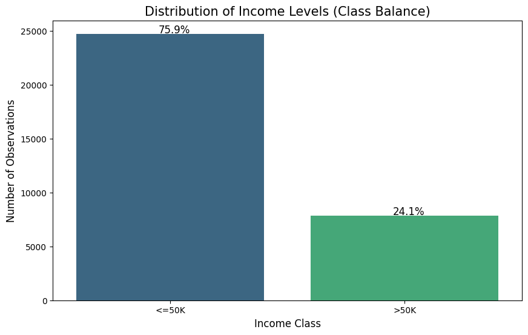

```python
# Calculate counts and proportions
class_counts = census_data['income'].value_counts()
class_proportions = census_data['income'].value_counts(normalize=True) * 100

print("Class Distribution:")
print(class_counts)
print("\nProportions (%):")
print(class_proportions)

# Visualization for distribution of target variable
plt.figure(figsize=(10, 6))
ax = sns.countplot(x='income', data=census_data, palette='viridis')

# labels
plt.title('Distribution of Income Levels (Class Balance)', fontsize=15)
plt.xlabel('Income Class', fontsize=12)
plt.ylabel('Number of Observations', fontsize=12)

for p in ax.patches:
    percentage = '{:.1f}%'.format(100 * p.get_height() / len(census_data))
    x = p.get_x() + p.get_width() / 2 - 0.05
    y = p.get_height() + 100
    ax.annotate(percentage, (x, y), size=12)

plt.show()
```

The census dataset exhibits a significant class imbalance. Approximately 75.9% of the individuals in the census earn ≤50K per year, while only 24.1% earn >50K.

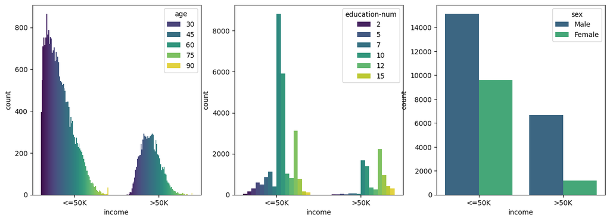

```python
fig, axes = plt.subplots(1, 3, figsize=(15, 5))
sns.countplot(x='income', hue='age', data=census_data, palette='viridis', ax=axes[0])
sns.countplot(x='income', hue='education-num', data=census_data, palette='viridis', ax=axes[1])
sns.countplot(x='income', hue='sex', data=census_data, palette='viridis', ax=axes[2])
plt.show()
```

```python
#compare number of men and women
print(census_data['sex'].value_counts())
print(f"\nDifference: {census_data['sex'].value_counts()[0] - census_data['sex'].value_counts()[1]}")
```

```
sex
Male      21790
Female    10771
Name: count, dtype: int64

Difference: 11019
```

The first graph (left) is on income and age. Apart from the already-mentioned class disparity between high and low income earners, there is also a disparity between people of age 30 who are high and low income, furthermore older people are present in both high and low income groups.

The second graph (middle) is on income and education-num, where the number corresponds to the years of education (2: 2nd grade). Years in education is not expected to scale linearly, as in comparing a 25 and 15 year old is not the same as comparing a 40 and 30 year old, younger people (especially below working age) are not expected to be making a lot of money, if any at all.

The third graph (right) compares the number of males and females from both classes; in both classes males clearly outnumber women. There are also more males part of the high income group. This graph implies there is another disparity between the subclass, sex, where females are underrepresented. We can confirm this in the cell below.

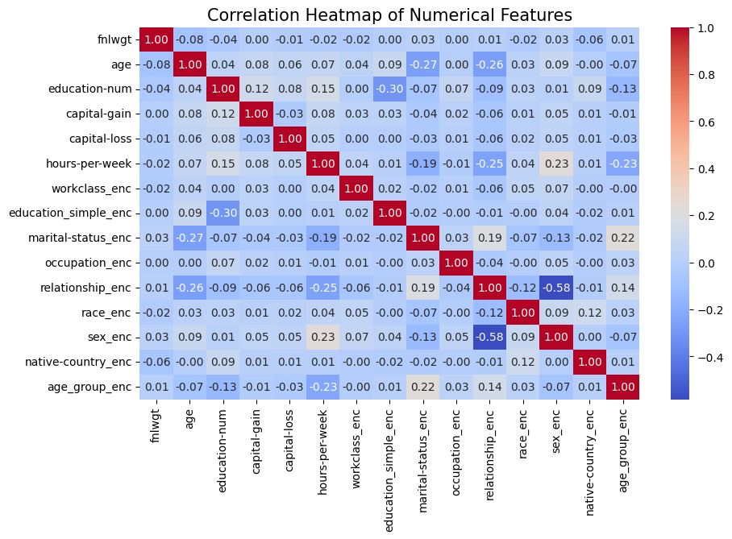

```python
#heatmap of all numerical features
plt.figure(figsize=(10, 6))
sns.heatmap(X.corr(), annot=True, cmap='coolwarm', fmt=".2f")
plt.title('Correlation Heatmap of Numerical Features', fontsize=15)
plt.show()
```

```python
X.head()
```

|  | fnlwgt | age | education-num | capital-gain | capital-loss | hours-per-week | workclass_enc | education_simple_enc | marital-status_enc | occupation_enc | relationship_enc | race_enc | sex_enc | native-country_enc | age_group_enc |
| --- | --- | --- | --- | --- | --- | --- | --- | --- | --- | --- | --- | --- | --- | --- | --- |
| 0 | 77516 | 39 | 13 | 2174 | 0 | 40 | 6 | 0 | 4 | 0 | 1 | 4 | 1 | 38 | 0 |
| 1 | 83311 | 50 | 13 | 0 | 0 | 13 | 5 | 0 | 2 | 3 | 0 | 4 | 1 | 38 | 2 |
| 2 | 215646 | 38 | 9 | 0 | 0 | 40 | 3 | 4 | 0 | 5 | 1 | 4 | 1 | 38 | 0 |
| 3 | 234721 | 53 | 7 | 0 | 0 | 40 | 3 | 3 | 2 | 5 | 0 | 2 | 1 | 38 | 2 |
| 4 | 338409 | 28 | 13 | 0 | 0 | 40 | 3 | 0 | 2 | 9 | 5 | 2 | 0 | 4 | 0 |

#### **2. Model Training**

```python
X, y, feature_names = prepare_features(census_processed)
# Train-test split
X_train, X_test, y_train, y_test = train_test_split(X, y, test_size=0.2, random_state=42, stratify=y)

# Scaler for Boosting and Random Forest
scaler = StandardScaler()
X_train_scaled = scaler.fit_transform(X_train)
X_test_scaled = scaler.transform(X_test)

print(f"Training set size: {X_train.shape[0]}")
print(f"Y_train shape: {y_train.shape[0]}")
print(f"\nTest set size: {X_test.shape[0]}")
print(f"Y_test shape: {y_test.shape[0]}")
```

```
Training set size: 26048
Y_train shape: 26048

Test set size: 6513
Y_test shape: 6513
```

```python
# 1. Logistic Regression (Baseline)
logreg = LogisticRegression(max_iter=1000, random_state=42)
logreg.fit(X_train_scaled, y_train)
y_train_pred_log = logreg.predict(X_train_scaled)
y_test_pred_log = logreg.predict(X_test_scaled)

# 2. Logistic Regression with Lasso Regularization (CV Tuned C)
# Cs=10 tests 10 logarithmically spaced values for C (inverse of regularization strength)
logreg_lasso_cv = LogisticRegressionCV(Cs=10, cv=5, penalty='l1', solver='saga', max_iter=1000, random_state=42)
logreg_lasso_cv.fit(X_train_scaled, y_train)
y_train_pred_log_lasso = logreg_lasso_cv.predict(X_train_scaled)
y_test_pred_log_lasso = logreg_lasso_cv.predict(X_test_scaled)

# 3. Logistic Regression with Ridge Regularization (CV Tuned C)
logreg_ridge_cv = LogisticRegressionCV(Cs=10, cv=5, penalty='l2', solver='saga', max_iter=1000, random_state=42)
logreg_ridge_cv.fit(X_train_scaled, y_train)
y_train_pred_log_ridge = logreg_ridge_cv.predict(X_train_scaled)
y_test_pred_log_ridge = logreg_ridge_cv.predict(X_test_scaled)

# 4. Logistic Regression with ElasticNet Regularization (CV Tuned C & l1_ratio)
logreg_elastic_cv = LogisticRegressionCV(
    Cs=10, l1_ratios=[0.1, 0.5, 0.9], cv=5, penalty='elasticnet',
    solver='saga', max_iter=1000, random_state=42
)
logreg_elastic_cv.fit(X_train_scaled, y_train)
y_train_pred_log_elastic = logreg_elastic_cv.predict(X_train_scaled)
y_test_pred_log_elastic = logreg_elastic_cv.predict(X_test_scaled)

# 5. Random Forest (GridSearchCV Auto-Tuning)
rf_params = {
    'n_estimators': [50, 100, 200],
    'max_depth': [10, 20, None],
    'max_features': ['sqrt', 'log2', None]
}
rf = RandomForestClassifier(random_state=42)
rf_grid = GridSearchCV(rf, rf_params, cv=5, n_jobs=-1, scoring='accuracy')
rf_grid.fit(X_train_scaled, y_train)
y_train_pred_rf = rf_grid.predict(X_train_scaled)
y_test_pred_rf = rf_grid.predict(X_test_scaled)

# 6. Gradient Boosting (GridSearchCV Auto-Tuning)
gb_params = {
    'n_estimators': [50, 100, 200],
    'max_depth': [3, 5, 7],
    'learning_rate': [0.01, 0.1, 0.2]
}
grad_boost = GradientBoostingClassifier(random_state=42)
gb_grid = GridSearchCV(grad_boost, gb_params, cv=5, n_jobs=-1, scoring='accuracy')
gb_grid.fit(X_train_scaled, y_train)
y_train_pred_gb = gb_grid.predict(X_train_scaled)
y_test_pred_gb = gb_grid.predict(X_test_scaled)
```

```python
best_params_dict = {
    "Logistic Regression (Baseline)": "None (Standard LogReg)",
    "Logistic Regression with Lasso": f"C: {logreg_lasso_cv.C_[0]:.5f}",
    "Logistic Regression with Ridge": f"C: {logreg_ridge_cv.C_[0]:.5f}",
    "Logistic Regression with ElasticNet": f"C: {logreg_elastic_cv.C_[0]:.5f}, l1_ratio: {logreg_elastic_cv.l1_ratio_[0]:.5f}",
    "Random Forest": ", ".join([f"{k}: {v}" for k, v in rf_grid.best_params_.items()]),
    "Gradient Boosting": ", ".join([f"{k}: {v}" for k, v in gb_grid.best_params_.items()])
}

def get_metrics(y_true, y_pred, model_name, dataset_type, hyperparams):
    return {
        "Model": model_name,
        "Dataset": dataset_type,
        "Best Hyperparameters": hyperparams,
        "Accuracy": accuracy_score(y_true, y_pred),
        "Precision": precision_score(y_true, y_pred, zero_division=0),
        "Recall": recall_score(y_true, y_pred, zero_division=0),
        "F1-Score": f1_score(y_true, y_pred, zero_division=0),
    }

models_preds = [
    ("Logistic Regression", y_train_pred_log, y_test_pred_log),
    ("Logistic Regression with Lasso", y_train_pred_log_lasso, y_test_pred_log_lasso),
    ("Logistic Regression with Ridge", y_train_pred_log_ridge, y_test_pred_log_ridge),
    ("Logistic Regression with ElasticNet", y_train_pred_log_elastic, y_test_pred_log_elastic),
    ("Random Forest", y_train_pred_rf, y_test_pred_rf),
    ("Gradient Boosting", y_train_pred_gb, y_test_pred_gb)
]

results = []
for name, train_pred, test_pred in models_preds:
    # Look up the hyperparameter string for the current model
    hp_string = best_params_dict.get(name, "N/A (Baseline)")

    # Append Train metrics
    results.append(get_metrics(y_train, train_pred, name, "Train", hp_string))
    # results.append(get_metrics(y_test, test_pred, name, "Test", hp_string))

metrics_df = pd.DataFrame(results)

pd.set_option('display.max_colwidth', None)

print("\nCombined Performance Metrics & Hyperparameters (Train)")
print(metrics_df.to_string(index=False))
```

```
Combined Performance Metrics & Hyperparameters (Train)
                              Model Dataset                                 Best Hyperparameters  Accuracy  Precision   Recall  F1-Score
                Logistic Regression   Train                                       N/A (Baseline)  0.825783   0.714781 0.460226  0.559930
     Logistic Regression with Lasso   Train                                           C: 0.35938  0.825783   0.714887 0.460067  0.559845
     Logistic Regression with Ridge   Train                                           C: 0.35938  0.825783   0.714887 0.460067  0.559845
Logistic Regression with ElasticNet   Train                        C: 0.04642, l1_ratio: 0.10000  0.825706   0.716463 0.457198  0.558194
                      Random Forest   Train max_depth: 20, max_features: sqrt, n_estimators: 200  0.958730   0.948722 0.875976  0.910899
                  Gradient Boosting   Train  learning_rate: 0.1, max_depth: 5, n_estimators: 200  0.896384   0.832033 0.713853  0.768426
```

#### **3. Feature Importance Analysis**

```python
feature_names = X_train.columns

def get_top_n_features(importances, names, n=7):
    abs_importances = np.abs(importances)

    top_indices = np.argsort(abs_importances)[::-1][:n]

    top_features = [f"{names[i]} ({abs_importances[i]:.4f})" for i in top_indices]
    return top_features

models_importances = {
    "LogRec (Baseline)": logreg.coef_[0],
    "LogReg (Lasso)": logreg_lasso_cv.coef_[0],
    "LogReg (Ridge)": logreg_ridge_cv.coef_[0],
    "LogReg (ElasticNet)": logreg_elastic_cv.coef_[0],
    "Random Forest": rf_grid.best_estimator_.feature_importances_,
    "Gradient Boosting": gb_grid.best_estimator_.feature_importances_
}

#dictionary for the DataFrame
top_features_dict = {}
for model_name, importances in models_importances.items():
    top_features_dict[model_name] = get_top_n_features(importances, feature_names, n=7)

top_features_df = pd.DataFrame(top_features_dict)
top_features_df.index = [f"Rank {i+1}" for i in range(7)]

pd.set_option('display.max_columns', None)
pd.set_option('display.width', 1000)

print("\nTop 7 Most Important Features by Model")
print("Note: Values are not normalized, and are therefore not comparable (Logit vs Random Forest, for example), this is meant to show the most important features for each model.")
print(top_features_df)
```

```
Top 7 Most Important Features by Model
Note: Values are not normalized, and are therefore not comparable (Logit vs Random Forest, for example), this is meant to show the most important features for each model.
                  LogRec (Baseline)               LogReg (Lasso)               LogReg (Ridge)          LogReg (ElasticNet)                Random Forest          Gradient Boosting
Rank 1        capital-gain (2.1999)        capital-gain (2.1956)        capital-gain (2.1761)        capital-gain (1.9786)        capital-gain (0.1360)  relationship_enc (0.3329)
Rank 2       education-num (0.8397)       education-num (0.8387)       education-num (0.8387)       education-num (0.8292)    relationship_enc (0.1337)      capital-gain (0.1987)
Rank 3                 age (0.5595)                 age (0.5577)                 age (0.5589)                 age (0.5523)                 age (0.1122)     education-num (0.1898)
Rank 4             sex_enc (0.4407)             sex_enc (0.4396)             sex_enc (0.4398)             sex_enc (0.4319)              fnlwgt (0.1089)      capital-loss (0.0632)
Rank 5      hours-per-week (0.3616)      hours-per-week (0.3607)      hours-per-week (0.3613)      hours-per-week (0.3579)       education-num (0.1061)               age (0.0623)
Rank 6  marital-status_enc (0.3045)  marital-status_enc (0.3037)  marital-status_enc (0.3042)  marital-status_enc (0.3008)      hours-per-week (0.0791)    hours-per-week (0.0468)
Rank 7        capital-loss (0.2604)        capital-loss (0.2597)        capital-loss (0.2599)        capital-loss (0.2558)  marital-status_enc (0.0763)            fnlwgt (0.0311)
```

```python
#Intersection
top_7_feature_sets = []

for model_name, importances in models_importances.items():
    abs_importances = np.abs(importances)
    top_indices = np.argsort(abs_importances)[::-1][:7]

    # Extract just the names of these top 7 features and convert to a set
    top_names = set(feature_names[i] for i in top_indices)
    top_7_feature_sets.append(top_names)

# The * unpacks the list so set.intersection can compare all of them at once
common_features = set.intersection(*top_7_feature_sets)

print("\nFeatures Appearing in the Top 7 Across ALL 6 Models")
if common_features:
    for feature in common_features:
        print(f"- {feature}")
else:
    print("No single feature appeared in the top 7 list for every single model.")
```

```
Features Appearing in the Top 7 Across ALL 6 Models
- education-num
- capital-gain
- age
- hours-per-week
```

#### Feature Importance Analysis

From the results, the features that appeared consistently across the top 7 lists for the six selected models were hours-per-week, age, education-num and capital-gain. The top 7 features were all consistent across all the same models, that is to say the four iterations of Logistic Regression (baseline, with Lasso, Ridge, and ElasticNet) all had the same top 7.

Below is a list of the features that never appeared in the top 7 of the models in feature importance.

```python
#features that NEVER appeared in the top 7 for any model
all_top_features = set()

for model_name, importances in models_importances.items():
    # Get the absolute importances
    abs_importances = np.abs(importances)

    # Get the indices of the top 7 features
    top_indices = np.argsort(abs_importances)[::-1][:7]

    # Extract just the names of these top 7 features and add to the set
    for i in top_indices:
        all_top_features.add(feature_names[i])

# The * operator unpacks the list so set.difference can compare all of them at once
unique_features = set(feature_names) - all_top_features

# 3. Display the results
print("\nFeatures That Never Appeared in the Top 7 Across ALL 6 Models")
if unique_features:
    for feature in unique_features:
        print(f"- {feature}")
else:    print("Every feature appeared in the top 7 list for at least one model.")
```

```
Features That Never Appeared in the Top 7 Across ALL 6 Models
- workclass_enc
- occupation_enc
- education_simple_enc
- native-country_enc
- age_group_enc
- race_enc
```

From this, we can see that some of the features that never appeared in the top 7 lists have overlap with features in the top 7 lists such as education_simple_enc to education_nu, age_group_enc to age. Others are simply encoded categorical variables whose affects are not easy to quantify such as native-country_enc.

#### **4. Model Performance Evalutation**

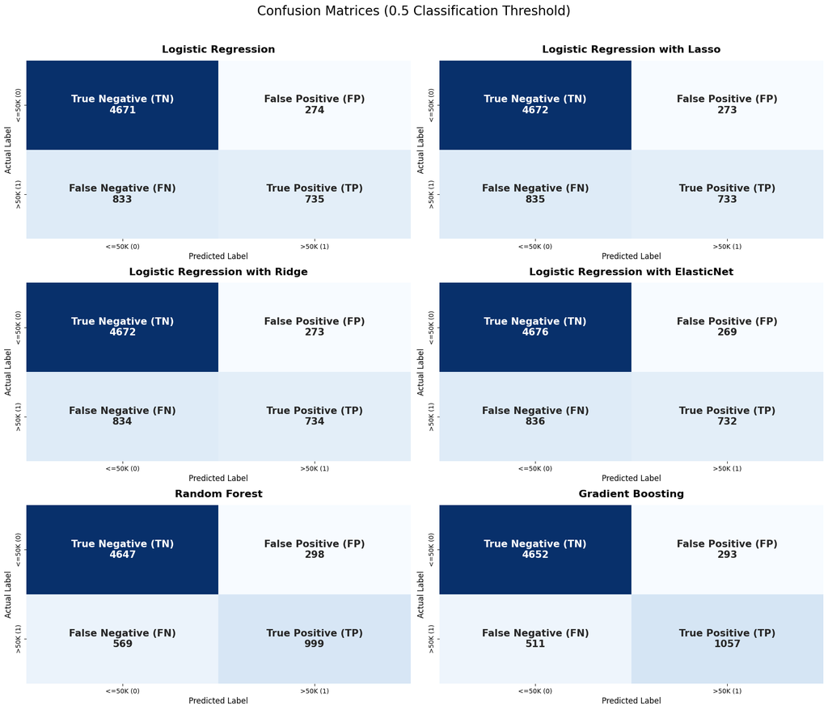

```python
# Group predictions for the loop
models_preds = [
    ("Logistic Regression", y_test_pred_log),
    ("Logistic Regression with Lasso", y_test_pred_log_lasso),
    ("Logistic Regression with Ridge", y_test_pred_log_ridge),
    ("Logistic Regression with ElasticNet", y_test_pred_log_elastic),
    ("Random Forest", y_test_pred_rf),
    ("Gradient Boosting", y_test_pred_gb)
]

# 2. Visualize in a 5x2 Grid with Explicit Labels
fig, axes = plt.subplots(3, 2, figsize=(18, 15))
fig.suptitle('Confusion Matrices (0.5 Classification Threshold)', fontsize=20, y=1.02)
axes = axes.flatten()

for i, (name, y_pred) in enumerate(models_preds):
    # Calculate raw confusion matrix
    cm = confusion_matrix(y_test, y_pred)

    # Define explicit text labels for the 4 quadrants
    # standard format: [[TN, FP], [FN, TP]]
    group_names = ['True Negative (TN)', 'False Positive (FP)',
                   'False Negative (FN)', 'True Positive (TP)']

    # Format counts and combine with text labels
    group_counts = ["{0:0.0f}".format(value) for value in cm.flatten()]
    labels = [f"{v1}\n{v2}" for v1, v2 in zip(group_names, group_counts)]
    labels = np.asarray(labels).reshape(2, 2)

    # Plot heatmap
    sns.heatmap(cm, annot=labels, fmt='', cmap='Blues', ax=axes[i],
                cbar=False, annot_kws={"size": 15, "weight": "bold"})

    # Formatting
    axes[i].set_title(name, fontsize=16, pad=12, weight='bold')
    axes[i].set_xlabel('Predicted Label', fontsize=12)
    axes[i].set_ylabel('Actual Label', fontsize=12)

    # Map 0 and 1 to actual class meanings for context
    axes[i].set_xticklabels(['<=50K (0)', '>50K (1)'])
    axes[i].set_yticklabels(['<=50K (0)', '>50K (1)'])

plt.tight_layout()
plt.show()
```

```python
def get_metrics(y_true, y_pred, model_name, dataset_type):
    # Extract components of the confusion matrix
    cm = confusion_matrix(y_true, y_pred)
    # Ensure it handles binary classification correctly
    if cm.shape == (2, 2):
        tn, fp, fn, tp = cm.ravel()
    else:
        tn, fp, fn, tp = 0, 0, 0, 0 # Fallback for edge cases

    # Calculate additional metrics
    specificity = tn / (tn + fp) if (tn + fp) > 0 else 0
    type1_error = fp / (tn + fp) if (tn + fp) > 0 else 0  # False Positive Rate
    type2_error = fn / (tp + fn) if (tp + fn) > 0 else 0  # False Negative Rate

    return {
        "Model": model_name,
        "Dataset": dataset_type,
        "Accuracy": accuracy_score(y_true, y_pred),
        "Precision": precision_score(y_true, y_pred, zero_division=0),
        "Recall": recall_score(y_true, y_pred, zero_division=0),
        "F1-Score": f1_score(y_true, y_pred, zero_division=0),
        # Multiply by 100 to format as percentages
        "Specificity (%)": specificity * 100,
        "Type 1 Error FPR (%)": type1_error * 100,
        "Type 2 Error FNR (%)": type2_error * 100
    }

models_preds = [
    ("Logistic Regression", y_train_pred_log, y_test_pred_log),
    ("Logistic Regression with Lasso", y_train_pred_log_lasso, y_test_pred_log_lasso),
    ("Logistic Regression with Ridge", y_train_pred_log_ridge, y_test_pred_log_ridge),
    ("Logistic Regression with ElasticNet", y_train_pred_log_elastic, y_test_pred_log_elastic),
    ("Random Forest (Depth 10)", y_train_pred_rf, y_test_pred_rf),
    ("Gradient Boosting", y_train_pred_gb, y_test_pred_gb)
]

results = []
for name, train_pred, test_pred in models_preds:
    #results.append(get_metrics(y_train, train_pred, name, "Train"))
    results.append(get_metrics(y_test, test_pred, name, "Test"))

metrics_df = pd.DataFrame(results)

print("\n Full Performance Metrics (Test)")
print(metrics_df.to_string(index=False))

# Isolate the Test dataset for fair evaluation
test_metrics = metrics_df[metrics_df["Dataset"] == "Test"]

# Rank by Accuracy
rank_accuracy = test_metrics.sort_values(by="Accuracy", ascending=False).reset_index(drop=True)
print("\nRanking by Accuracy (Test Set)")
print(rank_accuracy[['Model', 'Accuracy', 'Type 1 Error FPR (%)', 'Type 2 Error FNR (%)']].to_string(index=False))

# Rank by F1-Score
rank_f1 = test_metrics.sort_values(by="F1-Score", ascending=False).reset_index(drop=True)
print("\nRanking by F1-Score (Test Set)")
print(rank_f1[['Model', 'F1-Score', 'Precision', 'Recall']].to_string(index=False))
```

```
 Full Performance Metrics (Test)
                              Model Dataset  Accuracy  Precision   Recall  F1-Score  Specificity (%)  Type 1 Error FPR (%)  Type 2 Error FNR (%)
                Logistic Regression    Test  0.830032   0.728444 0.468750  0.570431        94.459050              5.540950             53.125000
     Logistic Regression with Lasso    Test  0.829879   0.728628 0.467474  0.569542        94.479272              5.520728             53.252551
     Logistic Regression with Ridge    Test  0.830032   0.728898 0.468112  0.570097        94.479272              5.520728             53.188776
Logistic Regression with ElasticNet    Test  0.830339   0.731269 0.466837  0.569872        94.560162              5.439838             53.316327
           Random Forest (Depth 10)    Test  0.866882   0.770239 0.637117  0.697382        93.973711              6.026289             36.288265
                  Gradient Boosting    Test  0.876555   0.782963 0.674107  0.724469        94.074823              5.925177             32.589286

Ranking by Accuracy (Test Set)
                              Model  Accuracy  Type 1 Error FPR (%)  Type 2 Error FNR (%)
                  Gradient Boosting  0.876555              5.925177             32.589286
           Random Forest (Depth 10)  0.866882              6.026289             36.288265
Logistic Regression with ElasticNet  0.830339              5.439838             53.316327
                Logistic Regression  0.830032              5.540950             53.125000
     Logistic Regression with Ridge  0.830032              5.520728             53.188776
     Logistic Regression with Lasso  0.829879              5.520728             53.252551

Ranking by F1-Score (Test Set)
                              Model  F1-Score  Precision   Recall
                  Gradient Boosting  0.724469   0.782963 0.674107
           Random Forest (Depth 10)  0.697382   0.770239 0.637117
                Logistic Regression  0.570431   0.728444 0.468750
     Logistic Regression with Ridge  0.570097   0.728898 0.468112
Logistic Regression with ElasticNet  0.569872   0.731269 0.466837
     Logistic Regression with Lasso  0.569542   0.728628 0.467474
```

#### Regularization Impact on Logistic Regression

Compared to the baseline Logistic Regression, the regularized versions were similar in accuracy and F1-score. The accuracy scores were all at around 0.83, while the F1-scores hovered around 0.56 to 0.57 for both training and testing sets. The type 1 and type 2 error rates were also similar in values, with the type 1 error at around 5.4% to 5.5%, and the type 2 error at around 53.1% to 53.3%.

#### Best Logisitc Regression Model vs. Best Ensemble Model

Comparing the best among the two groups, Logistic Regression models and Ensemble methods, the best were ElasticNet and Gradient boosting. From the results, Gradient Boosting consistently scored the highest across the different performance metrics, with the highest accuracy score at around 0.877, highest F1-score at around 0.724, highest recall at around 0.674, highest precision at around 0.783, lowest type 2 error rate at around 32.59% despite having the second highest type 1 error rate at around 5.93%.

One result worth mentioning is the tuned Random Forest having a max depth of 20, max features using the squareroot of the total number of features with 200 estimators. This tuned Random Forest had a training and testing accuracy of around 0.96 and 0.87 respectively, while having a training and testing F1-score of around 0.911 and 0.697. This drop off suggests that the Random Forest is overfitting and has high variance. No other model exhibits this drastic of a drop-off between the training and testing results. The Gradient Boosting, meanwhile does not have a drastic drop off in F1-score between the training and testing sets, (0.768 and 0.724 respectively). The Gradient Boosted model is more accurate while offering better predictive power.

#### **5. Model Recommendation**

#### Recommended Model: Gradient Boosting

Among the models, the Gradient Boosted model lands a recommendation. The recommended model has the highest accuracy while not suffering from overfitting like the other ensembled-based model, offering the best predictive power with the highest F1-score. The consistent high marks in the performance metrics make it the best model for this dataset. In terms of interpretability, the tree-based models offer better intuitive interpretability in its list of feature importance, and the hyperparameter tuning options allow for greater control.